# Final

Ziwen Zhang

2022-12-15

# Q1A

```r
data <- matrix(c(23, 13, 5, 7), nrow = 2)
data
```

```
##      [,1] [,2]
## [1,]   23    5
## [2,]   13    7
```

```r
diffProp <- data[1,1]/(data[1,1] + data[1,2]) - data[2,1]/(data[2,1] + data[2,2])

  pi1 <- data[1,1]/(data[1,1] + data[1,2])
  pi2 <- data[2,1]/(data[2,1] + data[2,2])
  low_DP <- diffProp - 1.96 * sqrt((pi1*(1-pi1))/(data[1,1]+data[1,2]) + (pi2*(1-pi2))/(data[2,1]+data[2,2]))
  upp_DP <- diffProp + 1.96 * sqrt((pi1*(1-pi1))/(data[1,1]+data[1,2]) + (pi2*(1-pi2))/(data[2,1]+data[2,2]))

paste("95% Wald confidence interval for the difference in probabilities of success conditioning on the strategy is from ", round(low_DP,3), "to", round(upp_DP,3))
```

```
## [1] "95% Wald confidence interval for the difference in probabilities of success conditioning on the strategy is from  -0.081 to 0.424"
```

Interpret: We have 95% confidence to conclude that probabilities of success conditioning on the strategy differ from -8.1% to 42.4%. Since this interval includes 0, it is hard to conclude that which strategy is better.

# Q1B

```r
  relative_risk1 <- data[1,1]/(data[1,1] + data[1,2])
  relative_risk2 <- data[2,1]/(data[2,1] + data[2,2])
  relative_risk_ratio <- relative_risk1 / relative_risk2

  low_RR <- exp((ln(relative_risk_ratio) - 1.96 * sqrt(1/data[1,1] + 1/data[2,1] - 1/(data[1,1] + data[1,2]) - 1/(data[2,1] + data[2,2]))))
  upp_RR <- exp((ln(relative_risk_ratio) + 1.96 * sqrt(1/data[1,1] + 1/data[2,1] - 1/(data[1,1] + data[1,2]) - 1/(data[2,1] + data[2,2]))))

paste("relative risk ratio: ", round(relative_risk_ratio,3), "95% CI for relative risk ratio is from ", round(low_RR,3), "to", round(upp_RR,3))
```

```
## [1] "relative risk ratio:  1.264 95% CI for relative risk ratio is from  0.877 to 1.821"
```

Interpret: Since 95% CI includes 1, there is no significant difference in probabilities of success conditioning on the strategy.

# Q1C

```r
  odds1 <- data[1,1] / data[1,2]
  odds2 <- data[2,1] / data[2,2]
  odds_ratio <- odds1 / odds2

  low_OR <- exp((ln(odds_ratio) - 1.96 * sqrt(1/data[1,1] + 1/data[1,2] + 1/data[2,1] + 1/data[2,2])))
  upp_OR <- exp((ln(odds_ratio) + 1.96 * sqrt(1/data[1,1] + 1/data[1,2] + 1/data[2,1] + 1/data[2,2])))

paste("odds ratio: ", round(odds_ratio,3), "95% CI for odds ratio is from ", round(low_OR,3), "to", round(upp_OR,3))
```

```
## [1] "odds ratio:  2.477 95% CI for odds ratio is from  0.652 to 9.403"
```

Interpret: Since 95% CI includes 1, there is no significant difference in probabilities of success conditioning on the strategy.

# Q1D

There is no sufficient evidence to conclude that calling time-out is a good strategy.

Firstly, the 95% Wald confidence interval includes 0 and ranges from a negative value to a positive value, indicating that there is no significant difference on probability of success between two strategies.

Secondly, even though the odds ration and relative risk are larger than 1, the 95% CI for the both include 1, indicating that there is no significant difference in probabilities of success conditioning on the strategy.

# Q2A

```r
library(survminer)
library(tidyverse)
library(survival)
```

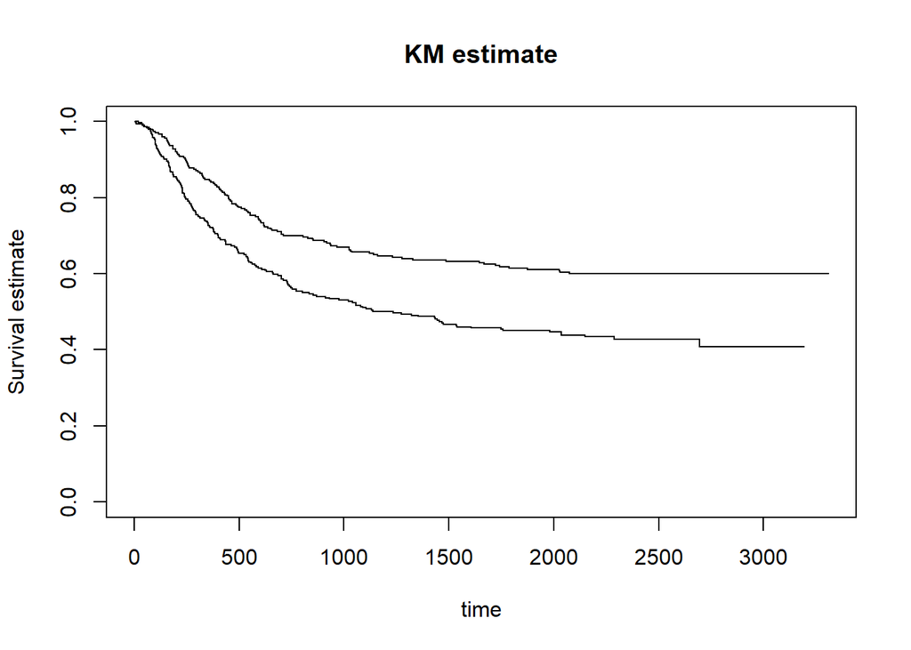

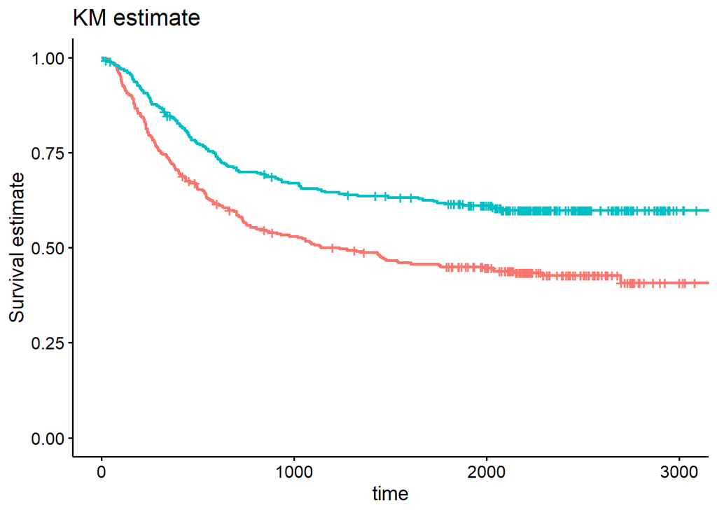

```r
library(KMsurv)

KM_est = survfit(Surv(time, status) ~ rx, type = "kaplan-meier", conf.type ="log", data = clinical_trial)

plot(KM_est, main = "KM estimate", xlab = "time", ylab = "Survival estimate")
ggsurvplot(KM_est, legend = "none") +
  xlab( "time") +
  ylab("Survival estimate") +
  ggtitle("KM estimate")
```

```r
logrank_test <- survdiff(Surv(time, status) ~ rx, data = clinical_trial)
logrank_test
```

```
## Call:
## survdiff(formula = Surv(time, status) ~ rx, data = clinical_trial)
##
##                      N Observed Expected (O-E)^2/E (O-E)^2/V
## rx=control         315      177      140     10.05      19.1
## rx=novel_treatment 304      119      156      8.96      19.1
##
##  Chisq= 19.1  on 1 degrees of freedom, p= 1e-05
```

Interpret: Since the p-value of the log-rank test is < 0.05, there is an evidence to reject the null hypothesis and thus there is a difference between the populations (control group and novel treatment group) in the probability of death at any time.

# Q2B

```r
# summary(KM_est)
```

# Q2C

```r
library(survival)

coxfit <- coxph(Surv(time, status) ~ rx, data = clinical_trial)
coxfit
```

```
## Call:
## coxph(formula = Surv(time, status) ~ rx, data = clinical_trial)
##
##                      coef exp(coef) se(coef)      z        p
## rxnovel_treatment -0.5126    0.5989   0.1187 -4.319 1.56e-05
##
## Likelihood ratio test=19.09  on 1 df, p=1.249e-05
## n= 619, number of events= 296
```

Since the p-value is smaller than 0.05, there is an evidence to reject the null hypothesis and thus the treatment effect is significant.

# Q2D

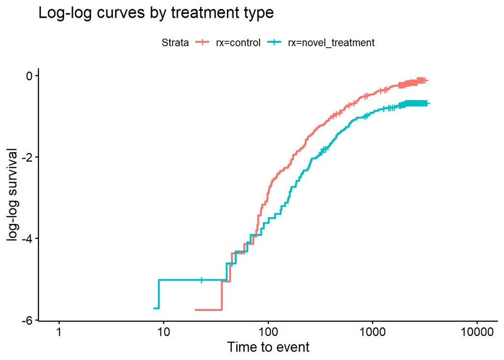

```r
library(survminer)

ph_fit <- survfit(Surv(time, status) ~ rx, data = clinical_trial)

ggsurvplot(ph_fit, fun = "cloglog", data = clinical_trial) +
  labs(title = "Log-log curves by treatment type",
       y = "log-log survival",
       x = "Time to event")
```

# Q2E

```r
surv_median(KM_est, combine = TRUE)
```

```
##               strata median lower upper
## 1         rx=control   1236   803  2036
## 2 rx=novel_treatment     NA    NA    NA
```

# Q3A

H0: There is no difference in the rate of staphylococcus infection between patients whose burns were cared for with a routine bathing care method (trt = 0) versus those whose body cleansing was initially performed using 4% chlorhexidine gluconate (trt = 1)

H1: There is a difference in the rate of staphylococcus infection between patients whose burns were cared for with a routine bathing care method (trt = 0) versus those whose body cleansing was initially performed using 4% chlorhexidine gluconate (trt = 1)

```r
log_rank <- survdiff(Surv(time, status) ~ trt, data = staph)
log_rank
```

```
## Call:
## survdiff(formula = Surv(time, status) ~ trt, data = staph)
##
##        N Observed Expected (O-E)^2/E (O-E)^2/V
## trt=0 70       28     21.4      2.07      3.79
## trt=1 84       20     26.6      1.66      3.79
##
##  Chisq= 3.8  on 1 degrees of freedom, p= 0.05
```

```r
prop.test(x = c(28, 20), n = c(70, 84), alternative = "two.sided")
```

```
##
##  2-sample test for equality of proportions with continuity correction
##
## data:  c(28, 20) out of c(70, 84)
## X-squared = 3.9411, df = 1, p-value = 0.04712
## alternative hypothesis: two.sided
## 95 percent confidence interval:
##  0.002294312 0.321515212
## sample estimates:
##    prop 1    prop 2
## 0.4000000 0.2380952
```

Since the p-value is <= 0.05, there is an evidence to reject the null hypothesis and thus there is a difference in the rate of staphylococcus infection between patients whose burns were cared for with a routine bathing care method (trt = 0) versus those whose body cleansing was initially performed using 4% chlorhexidine gluconate (trt = 1).

```r
FH_est = survfit(Surv(time, status) ~ trt, type = "fleming-harrington", data = staph)

# ggsurvplot(FH_est, fun = "cumhaz", data = staph) +
  labs(title = "Survival curves",
       y = "cumulative hazard",
       x = "Time")
```

[output not shown]

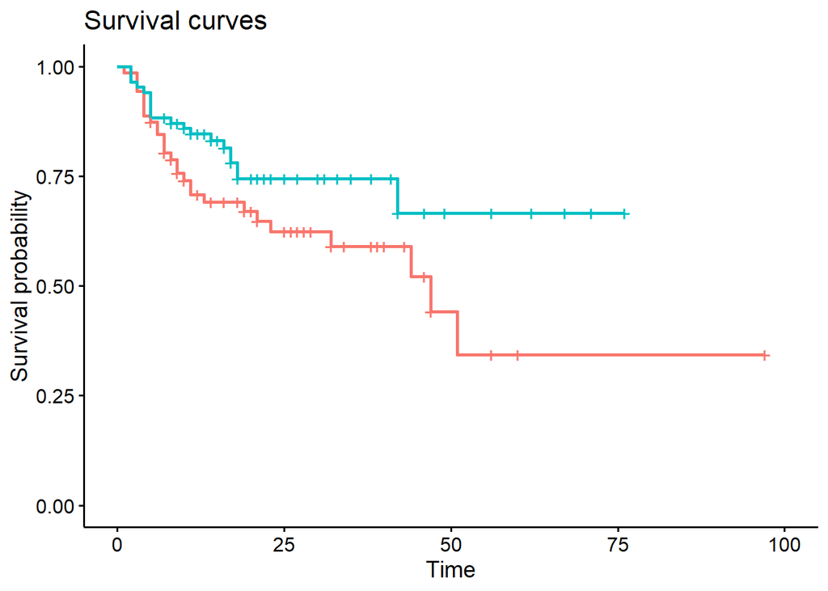

```r
ggsurvplot(FH_est, legend = "none") +
  labs(title = "Survival curves",
       y = "Survival probability",
       x = "Time")
```

Interpret: the survival curves shows the consistent results with the results obtained from the test, and there is a difference of the survival curve between the two treatment groups.

# Q3B

```r
library(RISCA)
library(survRM2)
RMSTdiff30 <- rmst2(time = staph$time, status = staph$status, arm = staph$trt, tau = 30, covariates = NULL, alpha = 0.05)
RMSTdiff30
```

```
##
## The truncation time: tau = 30  was specified.
##
## Restricted Mean Survival Time (RMST) by arm
##                Est.    se lower .95 upper .95
## RMST (arm=1) 24.754 1.068    22.661    26.847
## RMST (arm=0) 22.047 1.338    19.426    24.669
##
##
## Restricted Mean Time Lost (RMTL) by arm
##               Est.    se lower .95 upper .95
## RMTL (arm=1) 5.246 1.068     3.153     7.339
## RMTL (arm=0) 7.953 1.338     5.331    10.574
##
##
## Between-group contrast
##                       Est. lower .95 upper .95     p
## RMST (arm=1)-(arm=0) 2.707    -0.648     6.061 0.114
## RMST (arm=1)/(arm=0) 1.123     0.970     1.299 0.120
## RMTL (arm=1)/(arm=0) 0.660     0.393     1.107 0.115
```

```r
RMSTdiff60 <- rmst2(time = staph$time, status = staph$status, arm = staph$trt, tau = 60, covariates = NULL, alpha = 0.05)
RMSTdiff60
```

```
##
## The truncation time: tau = 60  was specified.
##
## Restricted Mean Survival Time (RMST) by arm
##                Est.    se lower .95 upper .95
## RMST (arm=1) 45.473 2.875    39.838    51.109
## RMST (arm=0) 36.409 3.194    30.149    42.669
##
##
## Restricted Mean Time Lost (RMTL) by arm
##                Est.    se lower .95 upper .95
## RMTL (arm=1) 14.527 2.875     8.891    20.162
## RMTL (arm=0) 23.591 3.194    17.331    29.851
##
##
## Between-group contrast
##                       Est. lower .95 upper .95     p
## RMST (arm=1)-(arm=0) 9.064     0.642    17.487 0.035
## RMST (arm=1)/(arm=0) 1.249     1.010     1.544 0.040
## RMTL (arm=1)/(arm=0) 0.616     0.385     0.985 0.043
```

Interpret: When tau = 30, RMST for trt=1 is 24.754, RMST for trt=0 is 22.047 and RMSTdiff is 2.707. When tau = 60, RMST for trt=1 is 45.473, RMST for trt=0 is 36.409 and RMSTdiff is 9.064. From this result, we can see that the increase of tau will increase the RMST for both of the arms and the difference between RMST will also increase.

# Q4A

TRUE

# Q4B

TRUE

# Q4C

TRUE